# Домашняя работа № 1 - Оформление ноутбука и закрепление функций и генераторов

## Задание 2

На складе лежат разные фрукты в разном количестве. Нужно написать функцию, которая на вход принимает любое количество названий фруктов и их количество, а возвращает общее количество фруктов на складе.

```python
def total_fruits(**kwargs) -> int:
    try:
        return(sum(kwargs.values()))
    except TypeError:
        print('Ошибка в данных')
```

```python
total_fruits(banana=5, mango=7, apple=8)
```

```
20
```

```python
total_fruits(banana='etre', mango=7, apple=8)
```

```
Ошибка в данных
```

## Задание 3

Дан список с затратами на рекламу. Но в данных есть ошибки, некоторые затраты имеют отрицательную величину.  
Удалите такие значения из списка и посчитайте суммарные затраты  
[100, 125, -90, 345, 655, -1, 0, 200]

Используйте list comprehensions

```python
def sum_posi(list_1: list) -> int:
    return(sum([item for item in list_1 if item > 0]))
```

100, 125, -90, 345, 655, -1, 0, 200

-5, -5, -5, -5, -5

100, 100, 100, -100, -100, -100

```python
sum_posi(map(int,input("Введите числа через запятую\n").split(',')))
```

```
Введите числа через запятую
100, 125, -90, 345, 655, -1, 0, 200
```

```
1425
```

## Задание 4

Даны два списка.  
Дата покупки  
['2021-09-14', '2021-12-15', '2021-09-08', '2021-12-05', '2021-10-09', '2021-09-30', '2021-12-22', '2021-11-29', '2021-12-24', '2021-11-26', '2021-10-27', '2021-12-18', '2021-11-09', '2021-11-23', '2021-09-27', '2021-10-02', '2021-12-27', '2021-09-20', '2021-12-13', '2021-11-01', '2021-11-09', '2021-12-06', '2021-12-08', '2021-10-09', '2021-10-31', '2021-09-30', '2021-11-09', '2021-12-13', '2021-10-26', '2021-12-09']

Суммы покупок по датам  
[1270, 8413, 9028, 3703, 5739, 4095, 295, 4944, 5723, 3701, 4471, 651, 7037, 4274, 6275, 4988, 6930, 2971, 6592, 2004, 2822, 519, 3406, 2732, 5015, 2008, 316, 6333, 5700, 2887]

### 4.1 Найдите, какая выручка у компании в ноябре

Используйте list comprehensions

#### Данные:

'2021-09-14', '2021-12-15', '2021-09-08', '2021-12-05', '2021-10-09', '2021-09-30', '2021-12-22', '2021-11-29', '2021-12-24', '2021-11-26', '2021-10-27', '2021-12-18', '2021-11-09', '2021-11-23', '2021-09-27', '2021-10-02', '2021-12-27', '2021-09-20', '2021-12-13', '2021-11-01', '2021-11-09', '2021-12-06', '2021-12-08', '2021-10-09', '2021-10-31', '2021-09-30', '2021-11-09', '2021-12-13', '2021-10-26', '2021-12-09'

1270, 8413, 9028, 3703, 5739, 4095, 295, 4944, 5723, 3701, 4471, 651, 7037, 4274, 6275, 4988, 6930, 2971, 6592, 2004, 2822, 519, 3406, 2732, 5015, 2008, 316, 6333, 5700, 2887

```python
def sum_turnover(dates: list, sums: list, month0='11') -> int:
    return(sum([sums[i] for i in range(len(sums)) if dates[i][1] == month0]))
```

#### Пояснения:

Можно просто нажать "Enter", тогда будут использованы значения по умолчанию.

Или можно изменить данные на любом этапе.

```python
dates_default = "'2021-09-14', '2021-12-15', '2021-09-08', '2021-12-05', '2021-10-09', '2021-09-30', '2021-12-22', '2021-11-29', '2021-12-24', '2021-11-26', '2021-10-27', '2021-12-18', '2021-11-09', '2021-11-23', '2021-09-27', '2021-10-02', '2021-12-27', '2021-09-20', '2021-12-13', '2021-11-01', '2021-11-09', '2021-12-06', '2021-12-08', '2021-10-09', '2021-10-31', '2021-09-30', '2021-11-09', '2021-12-13', '2021-10-26', '2021-12-09'"
sum_default = "1270, 8413, 9028, 3703, 5739, 4095, 295, 4944, 5723, 3701, 4471, 651, 7037, 4274, 6275, 4988, 6930, 2971, 6592, 2004, 2822, 519, 3406, 2732, 5015, 2008, 316, 6333, 5700, 2887"

list_date = (input("Введите список дат через запятую (или нажмите Enter для использования списка по умолчанию):\n") or dates_default).replace("'","").split(', ')
for i in range(len(list_date)):
    list_date[i] = list_date[i].split('-')

list_sum = list(map(int, (input("\nВведите суммы покупок через запятую (или нажмите Enter):\n") or sum_default).split(', ')))

if input("\nВы хотите изменить месяц вычислений? По умолчанию: ноябрь. y/n:\n").lower() not in ['y', 'yes', 'д', 'да']:
    print("\nСумма оборотов по месяцу: ", sum_turnover(list_date, list_sum))
else:
    print("\nСумма оборотов по месяцу: ", sum_turnover(list_date, list_sum, input("Введите номер месяца, по которому вы хотите посчитать выручку:\n")))
```

```
Введите список дат через запятую (или нажмите Enter для использования списка по умолчанию):


Введите суммы покупок через запятую (или нажмите Enter):


Вы хотите изменить месяц вычислений? По умолчанию: ноябрь. y/n:


Сумма оборотов по месяцу:  25098
```

#### Проверка:

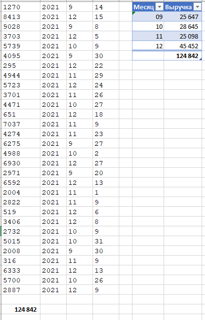

### 4.2 Найдите выручку компании в зависимости от месяца

Для этого напишите функцию, которая на вход принимает список с датами и список с выручкой, а на выходе словарь, где ключи - это месяцы, а значения - это выручка.  
Используйте аннотирование типов.

```python
def dict_sums(dates: list, sums: list) -> dict:
    d1 = dict.fromkeys(tuple(sorted(set([dates[i][1] for i in range(len(dates))]))), 0)
    for j in range(len(sums)):
        d1[dates[j][1]] += sums[j]
    print(d1)

dict_sums(list_date, list_sum)
```

```
{'09': 25647, '10': 28645, '11': 25098, '12': 45452}
```

#### Для иллюстрации.

Как хранятся два списка:

```python
print("Список дат:\n", list_date[0:3], sep="\n", end="\n")
```

```
Список дат:

[['2021', '09', '14'], ['2021', '12', '15'], ['2021', '09', '08']]
```

```python
print("Список сумм:\n", list_sum[0:3], sep="\n", end="\n")
```

```
Список сумм:

[1270, 8413, 9028]
```